# Fitting demographic models onto a time series

Camille Saade

17/05/2022

This course is largely inspired by Benjamin Rosenbaum’s work: https://benjamin-rosenbaum.github.io/fitting_deterministic_population_models/logistic_obs.html

In this course, we’ll see how to fit a demographic model onto experimental data. We’ll first illustrate the method with a simple example: fitting a logistic growth on a single-species time series. You’ll then get to adapt this code to more complicated cases (e.g., multispecific systems with several replicates).

We can already clean our environment and load libraries that will be common to all examples:

```r
# cleaning the env:
rm(list = ls())
# loading libraries:
library(rstan) #  for the stats
```

```r
library(ggplot2) # for some plots
library(coda) # diagnostic of mcmc output
library(deSolve) # to integrate ODEs
```

# I - Minimal exemple: logistic growth

Let us first try to fit a logistic model onto a toy time-series.

## a) Logistic model

As a reminder, the logistic growth model is written as:
$$\dfrac{dn}{dt} = rn(1-n/K)$$
where $n$ is the population density of a species with growth rate $r$ and carrying capacity $K$.

## b) Data

We have a dataset containing the density over time of a species in two different replicates

```r
full_data = read.csv('Data/logistic.csv')
head(full_data)
```

```
##   X time    density replicate
## 1 1    0   8.413343         1
## 2 2    3  23.070448         1
## 3 3    6  59.921342         1
## 4 4    9 126.859821         1
## 5 5   12 213.112977         1
## 6 6   15 292.589614         1
```

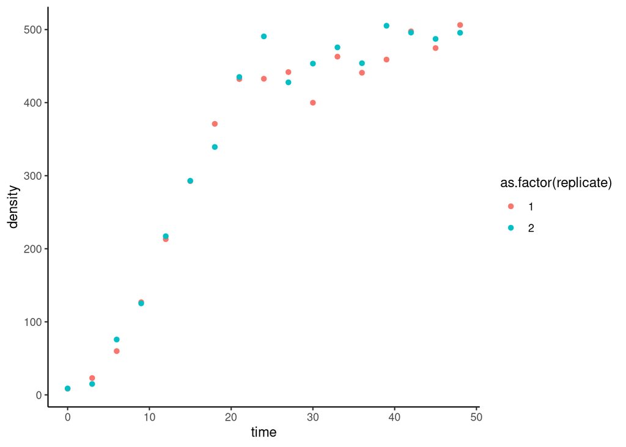

```r
ggplot(data = full_data) +
  geom_point(mapping = aes(x = time, y = density, color = as.factor(replicate))) +
  theme_classic()
```

For simplicity, we’ll only fit the data to a single replicate (we’ll discuss how to fit a single model on several replicates during the practice session).

```r
full_data = full_data[full_data$replicate == 1,]
```

Lastly, stan requires that the data is in the shape of a named list:

```r
data_stan = list(n = length(unique(full_data$time)), # the number of observations
                 t = full_data$time, # the vector of times
                 N = full_data$density) # the vector of densities
```

## c) Stan model declaration and compilation

We write the stan model as a C code string:

```r
logistic_model_str = '
functions{
  real[] odemodel(real t, real[] N, real[] p, real[] x_r, int[] x_i){
    // p[1]=r, p[2]=K
    real dNdt[1];
    dNdt[1] = p[1]*(1-(N[1]/p[2]))*N[1];
    return dNdt;
  }
}

data{
  int n; // number of observations
  real t[n]; // time
  real N[n]; // observations
}

parameters{
  real<lower=0> r; // growth rate
  real<lower=0> K; // carrying capacity
  real<lower=0> sdev; // error term
  real<lower=0> N0sim; // initial density distribution
}

model{
  real p[2]; // vector of parameters for the ODE
  real Nsim[n-1,1]; // simulated values, matrix. dim1 = time without t0, dim2 = dim_ODE = 1

  // priors
  r ~ lognormal(-0.5,1);
  K ~ lognormal(7,1);
  N0sim ~ normal(0,10);
  sdev ~ gamma(2,0.1);

  // parameters for integrator
  p[1] = r;
  p[2] = K;


  // integrate ODE
  Nsim = integrate_ode_rk45(odemodel, {N0sim}, t[1], t[2:n], p, rep_array(0.0,0), rep_array(0,0));
  // likelihood
  N[1] ~ normal(N0sim, sdev);
  for (i in 2:n){
    N[i] ~ normal(Nsim[i-1], sdev);
  }
}

generated quantities{
  real alpha = r/K;
}
'
```

Don’t worry if this chunk of code seems a bit obscure, we’ll explain it bloc by bloc:

### functions{ }

This bloc contains necessary functions to fit the model, i.e. the population’s growth equation (ODE) in our case. It is used for numerical integration in the likelyhood computation: in the “model” bloc, we integrate odemodel for a given parameter combination and compare the real data to the values obtained through integration.

Stan requires the exact format of parameters and output as written here (see stan documentation: https://mc-stan.org/docs/2_19/stan-users-guide/coding-an-ode-system.html): the time ‘t’, state of the system ‘N’ and parameters ‘p’. The last two parameters are required by rstan to pass additional data into the function, but won’t be used here.

```
functions{
  real[] odemodel(real t, real[] N, real[] p, real[] x_r, int[] x_i){
    // p[1]=r, p[2]=K
    real dNdt[1];
    dNdt[1] = p[1]*(1-(N[1]/p[2]))*N[1];
    return dNdt;
  }
}
```

### data{ }

In this bloc, declare the format in which you will pass your data to Stan with their type and dimension. We chose to write the number of observations as ‘n’ and the times and densities as vectors (‘t’, ‘N’) of length ‘n’.

```
data{
  int n; // number of observations
  real t[n]; // time
  real N[n]; // observations
}
```

### parameters{ }

Here, declare the type, name and dimension of the model parameters. We need to estimate the logistic growth parameters (‘r’ and ‘K’) and a parameter describing the distribution of the residuals (‘sdev’: the standard deviation of a normal distribution). We also infer the initial state of the time series (‘N0’) as its true state is unknown and using the observed state would cause the observation error to cascade down the predictions. All parameters are positive, which we specify in the type declaration (‘real<lower=0>’).

```
parameters{
  real<lower=0> r; // growth rate
  real<lower=0> K; // carrying capacity
  real<lower=0> sdev; // error term
  real<lower=0> N0sim; // initial density distribution
}
```

### model{ }

This bloc is the core of the Stan model, where we specify how to compute likelihood as well as the parameters priors. Let’s analyze it step by step. First, we declare variables that will be used to integrate the ODE: ‘p’ is an array that will store the ODE’s parameters, and Nsim will store its outputs:

```
  real p[2]; // vector of parameters for the ODE
  real Nsim[n-1,1]; // simulated values, matrix. dim1 = time without t0, dim2 = dim_ODE = 1
```

Then we declare priors for our parameters. As a rule of thumb, we want prior distributions to be informed by our knowledge of the system. For example, knowing that our time series converge to roughly 500 individuals, it would make no sense for the model to try out a K of 100000. By taking a look at our time series, we get an idea of our parameters range: - ‘K’ (the equilibrium density) is roughly in the 100-1000 range. - ‘r’ (the initial growth rate) is likely smaller than 1, as an ‘r’ of 1 would mean that the population doubles every unit of time at low density. - ‘N0’ is smaller than 50. We reflect this knowledge using the following priors:

```
  // priors
  r ~ lognormal(-0.5,1);
  K ~ lognormal(7,1);
  N0sim ~ normal(0,10);
  sdev ~ gamma(2,0.1);
```

The log-normal distribution is usually a good idea for parameters that do not need to get to close to 0. The gamma distribution is very flexible and playing around with its parameters allows us to get a distribution where the parameter can get arbitriraly close to 0. We won’t detail other possible prior functions, but don’t hesitate to check the rstan documentation on priors when setting up your own model: https://mc-stan.org/docs/2_29/functions-reference/continuous-distributions.html#continuous-distributions

We can quickly check our prior distribution visually: it should include the ranges we estimated. K prior looks like this:

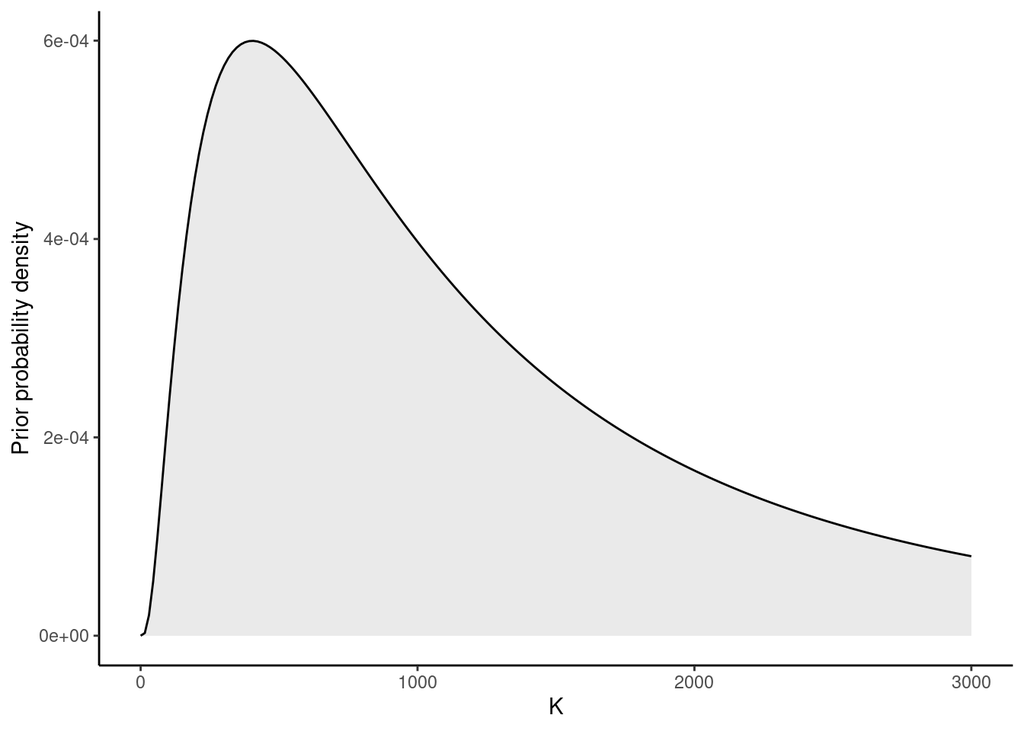

```r
x_K = seq(0, 3000, length.out = 200)
prior_K = dlnorm(x_K, 7, 1)
ggplot() +
  geom_ribbon(mapping = aes(x = x_K, ymin = 0, ymax = prior_K), alpha = 0.1) +
  geom_line(mapping = aes(x = x_K, y = prior_K)) +
  xlab('K') +
  ylab('Prior probability density') +
  theme_classic()
```

And r prior:

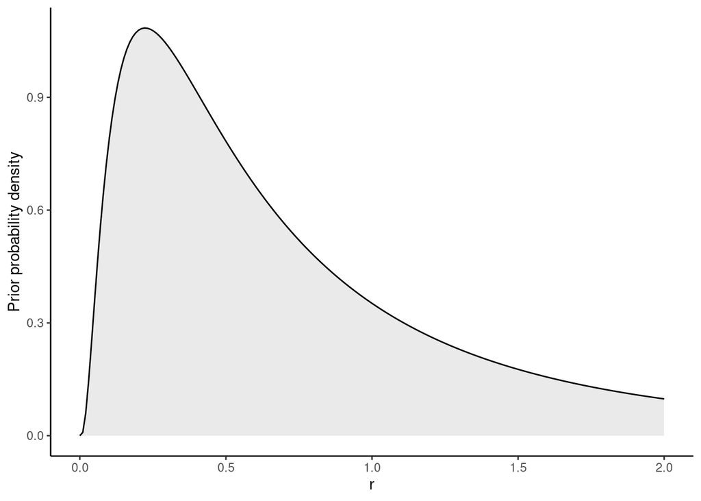

```r
x_r = seq(0, 2, length.out = 200)
prior_r = dlnorm(x_r, -0.5, 1)
ggplot() +
  geom_ribbon(mapping = aes(x = x_r, ymin = 0, ymax = prior_r), alpha = 0.1) +
  geom_line(mapping = aes(x = x_r, y = prior_r)) +
  xlab('r') +
  ylab('Prior probability density') +
  theme_classic()
```

Now that the priors are defined, we can go on to integrating the ODE an computing the likelihood. First we store the ODE parameters in the vector ‘p’, then we integrate the ODE using the function ‘integrate_ode_rk45’. The predicted time series is stored in ‘Nsim’. Lastely, we compute the likelihood using this time series. Likelihood is defined by a normal distribution: for each observation ‘Nsim[i]’, the likelihood follows a norma law centered on ‘Nsim[i-1]’ (mind the index gap).

```
  // parameters for integrator
  p[1] = r;
  p[2] = K;


  // integrate ODE
  Nsim = integrate_ode_rk45(odemodel, {N0sim}, t[1], t[2:n], p, rep_array(0.0,0), rep_array(0,0));
  // likelihood
  N[1] ~ normal(N0sim, sdev);
  for (i in 2:n){
    N[i] ~ normal(Nsim[i-1], sdev);
  }
```

### generated quantities{}

Lastly we can ask the model to compute additional quantities from the estimated parameters. We don’t really need it in this case but for the sake of exemple let’s ask for the $\alpha$ parameter which is equal to r over K:

```
generated quantities{
  real alpha = r/K;
}
```

### Model compilation

Now that the model is written, we can compile it:

```r
logistic_model = stan_model(model_code = logistic_model_str, auto_write = TRUE)
```

[output not shown]

## d) Model fit

We can finally fit the model. We start by declaring some model parameters. Because the logistic model is fairly simple, we don’t need too many samples to estimate the parameters so we’ll only use 3 chains of 2000 samples each (+ 2000 warmup steps that we’ll throw away)

```r
# stan options
chains = 3
options(mc.cores = chains)
iter   =  4000
warmup =  2000
```

We must also declare the values on which Stan will start the parameter estimation:

```r
# initial values for sampling
init=rep(list(list(r=0.1,
                   K=400,
                   N0sim=data_stan$N[1],
                   sdev=1))
         ,chains)
```

And lastly, we fit the model:

```r
fit = sampling(logistic_model,
               data=data_stan,
               iter=iter,
               warmup=warmup,
               chains=chains,
               init=init
)
```

## e) Model diagnostic

Once the fit is done, it is important to inspect the samples to ensure there are no pathological behaviors in the chain and that the estimates are correct.

### Effective number of samples and rhat

```r
print(fit, digits = 3)
```

```
## Inference for Stan model: 31f86a637b8f0e806a688634afaef6f7.
## 3 chains, each with iter=4000; warmup=2000; thin=1;
## post-warmup draws per chain=2000, total post-warmup draws=6000.
##
##          mean se_mean    sd    2.5%     25%     50%     75%   97.5% n_eff  Rhat
## r       0.282   0.001 0.029   0.233   0.262   0.279   0.299   0.346  1859 1.001
## K     462.240   0.151 8.615 445.661 456.436 462.250 467.820 479.171  3263 1.000
## sdev   24.192   0.082 4.462  17.173  21.009  23.618  26.711  34.605  2946 1.000
## N0sim  12.869   0.090 4.169   5.680   9.909  12.616  15.435  21.919  2127 1.001
## alpha   0.001   0.000 0.000   0.000   0.001   0.001   0.001   0.001  1860 1.001
## lp__  -57.742   0.033 1.491 -61.503 -58.484 -57.430 -56.644 -55.856  2038 1.001
##
## Samples were drawn using NUTS(diag_e) at Sun May 15 15:17:27 2022.
## For each parameter, n_eff is a crude measure of effective sample size,
## and Rhat is the potential scale reduction factor on split chains (at
## convergence, Rhat=1).
```

### Trace plot and density plot

We can also plot the trace and density of all parameters to check for anomalies. Density plots are ideally unimodal, and trace plots should show that the chains are well mixed:

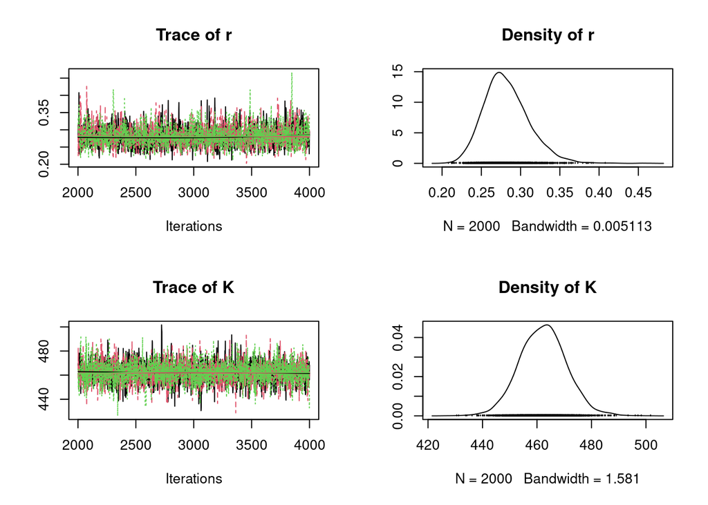

```r
samples=As.mcmc.list(fit)
plot(samples[, c("r","K")])
```

### Pair plot

We take a look at pair plots of parameters distribution to check that they are not correlated. Strongly correlated parameters are often non-identifiable as is results in many combination of parameters having the same likelihood, also called a “likelihood ridge”:

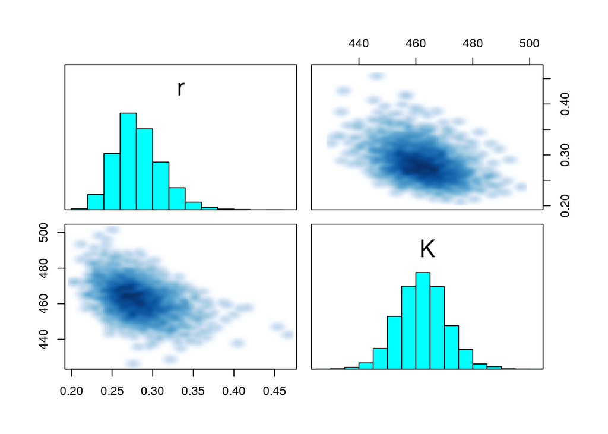

```r
pairs(fit, pars=c("r","K"))
```

### Priors vs. posteriors

Lastly, we can plot the distribution of priors and posteriors to check that the model indeed gained information from the data. Prior vs. posterior for K:

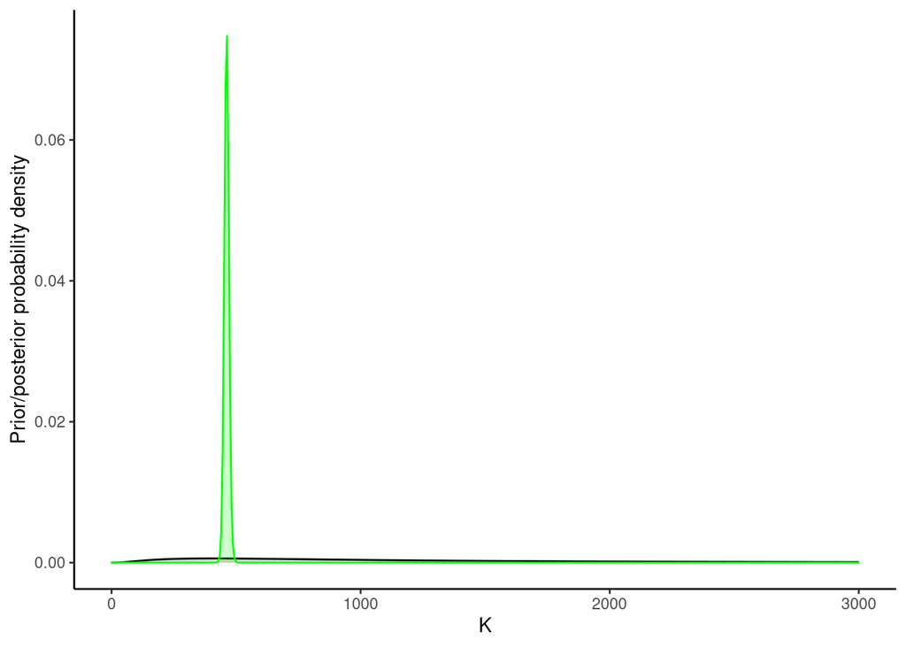

```r
ggplot() +
  geom_ribbon(mapping = aes(x = x_K, ymin = 0, ymax = prior_K), alpha = 0.2) +
  geom_line(mapping = aes(x = x_K, y = prior_K)) +
  geom_density(data = as.data.frame(fit), mapping = aes(x = K), color = 'green', fill = 'green', alpha = 0.2) +
  xlab('K') +
  ylab('Prior/posterior probability density') +
  theme_classic()
```

for r:

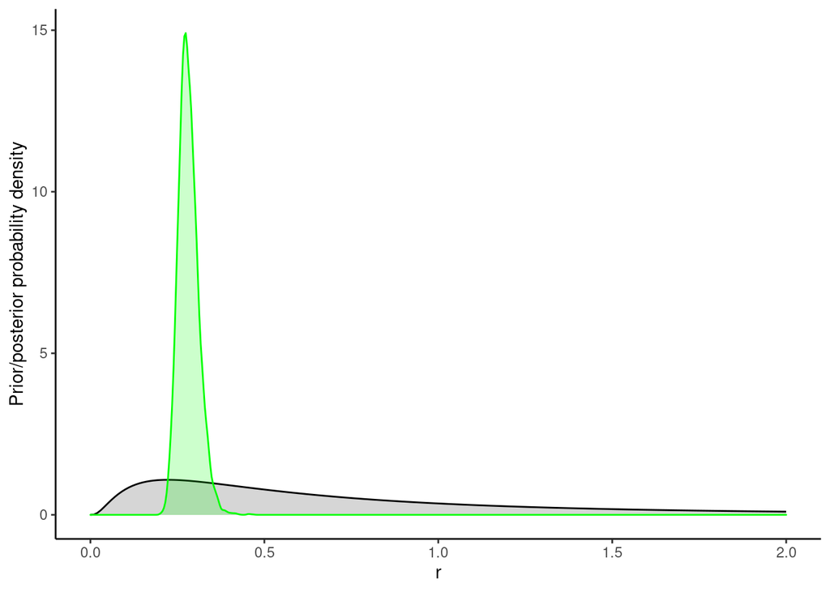

```r
ggplot() +
  geom_ribbon(mapping = aes(x = x_r, ymin = 0, ymax = prior_r), alpha = 0.2) +
  geom_line(mapping = aes(x = x_r, y = prior_r)) +
  geom_density(data = as.data.frame(fit), mapping = aes(x = r), color = 'green', fill = 'green', alpha = 0.2) +
  xlab('r') +
  ylab('Prior/posterior probability density') +
  theme_classic()
```

## f) Posterior predictions

Lastly, we can use the posterior distribution of parameters to make predictions. Here, we’ll use the inferred r, K and N0 to predict the median and confidence interval of the true time series. Let’s first declare the function ‘ode.model’ which returns the derivative of the logistic model. We’ll use it later to predict dynamics from the infered parameters:

```r
ode.model = function(t,N,p){
  dNdt =  p[1]*N[1]*(1.0-N[1]/p[2])
  return(list(dNdt))
}
```

Then we sample 1000 parameters combinations from the posterior distribution. we use these parameters to integrate the logistic model and store the resulting dynamics in a dataframe called “predictions”.

```r
posteriors = as.matrix(fit)
head(posteriors)
```

```
##           parameters
## iterations         r        K     sdev     N0sim        alpha      lp__
##       [1,] 0.2784771 468.2768 20.48446 14.332480 0.0005946849 -57.14682
##       [2,] 0.3147549 469.6914 43.79842  9.816205 0.0006701312 -62.93319
##       [3,] 0.3144817 467.7873 36.41517  6.008215 0.0006722750 -61.32108
##       [4,] 0.2797059 468.9791 22.34666 11.679859 0.0005964143 -56.15398
##       [5,] 0.2912605 455.1441 19.26565 11.967090 0.0006399304 -56.67469
##       [6,] 0.3087715 462.0932 21.12056  8.405922 0.0006682017 -56.62216
```

```r
n_post = 1000
times = seq(min(full_data$time), max(full_data$time), length.out = 40)

for (k in 1:n_post){
  par = posteriors[sample(1:nrow(posteriors), 1),]
  sim = ode(par['N0sim'], times, ode.model, c(par['r'], par['K']))

  temp  = data.frame(time = sim[,1], density = sim[,2], id = k)

  if (k == 1) {
    predictions = temp
  } else {
    predictions = rbind(predictions, temp)
  }

}
```

Just to make sure that the predictions seem correct, let us plot them all in a single plot:

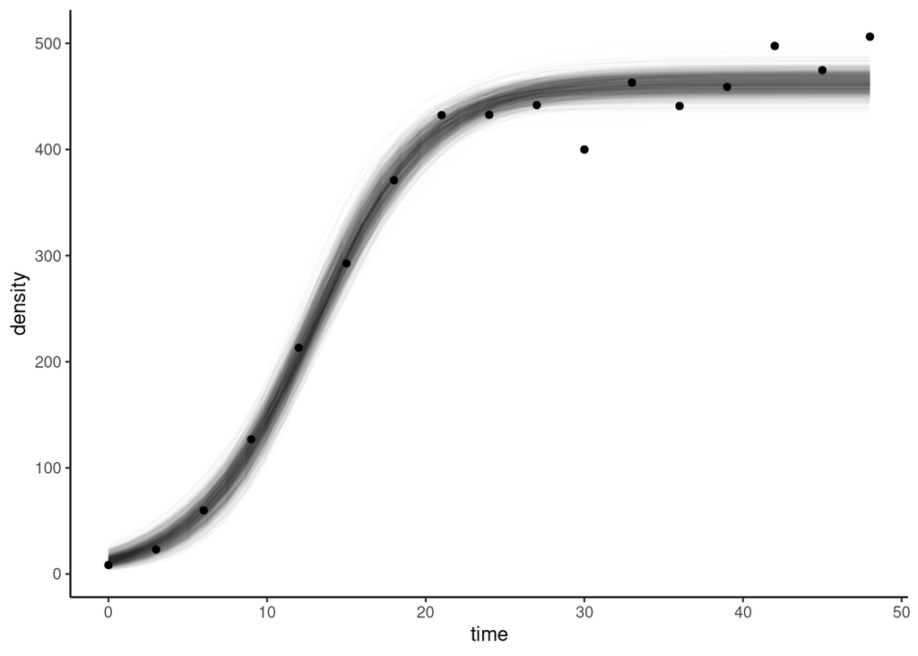

```r
ggplot() +
  geom_point(data = full_data[full_data$replicate == 1,], mapping = aes(x = time, y = density)) +
  geom_line(data = predictions, mapping = aes(x = time, y = density, group = id), alpha = 0.01) +
  theme_classic()
```

We can finally plot the median and confidence interval (0.05-0.95) of all the predictions:

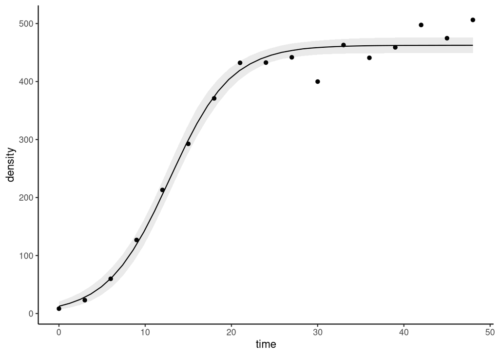

```r
ggplot() +
  geom_point(data = full_data[full_data$replicate == 1,], mapping = aes(x = time, y = density)) +
  stat_summary(data = predictions,
               fun.min = function(x) quantile(x, 0.05),
               fun.max = function(x) quantile(x, 0.95),
               mapping = aes(x = time, y = density),
               geom = 'ribbon', alpha = 0.1) +
  stat_summary(data = predictions,
               fun = median,
               mapping = aes(x = time, y = density),
               geom = 'line') +
  theme_classic()
```

# II - Practice

## a) Data description

Three datasets are available to you:

- epidemio.csv: Dynamics of an infectious disease: density over time of susceptible (S), infected (I) and recovered (R) inidividuals in 6 populations of similar sizes.
- competition.csv: Dynamics of two species in competition: density over time of species n1 and n2 in 6 different locations.
- predator_prey.csv: Dynamics of a trophic system: density over time of a prey (n) and its predator (p) in 6 different locations.

## b) Instructions

To help you navigate the fitting, here are some suggestions:

### Before you fit anything

- Chose one of the available datasets (preferably not all the same !). Before diving into fitting, make sure you understand the data structure and inspect it visually through plots.
- Think about which demographic model could fit your model and why. Write down its ODE and parameters parameters you need to estimate.

### Fit a model on a single replicate

To start with a simpler task, subset your data to keep only one of the replicates, and adapt the code from the minimal example above to fit onto your problem. In particular, in the declaration of the stan model you should modify:

- the “function” bloc to include the ODE your wrote down above.
- the “data” bloc to reflect the structure of your dataset.
- the “parameters” bloc according to the parameters you wrote down above.
- the “model” bloc. Pay particular attention to the prior declaration.

### Taking advantage of the replication: fitting a model on multiple time-series at once

If you have some time left, you can try fitting a single set of parameters on all the replicates at once. Benjamin Rosenbaum describes an elegant way to do that for a logistic example: https://benjamin-rosenbaum.github.io/fitting_deterministic_population_models/logistic_obs.html